# Презентация по лабораторной работе №16

Дисциплина: Имитационное моделирование

Лобанова П.И.

Российский университет дружбы народов, Москва, Россия

15 мая 2025

# Информация

## Докладчик

- Лобанова Полина Иннокентьевна
- Учащаяся на направлении “Фундаментальная информатика и информационные технологии”
- Студентка группы НФИбд-02-22
- polla-2004@mail.ru

# Цель

Реализовать с помощью GPSS-модели две стратегии обслуживания и оценить оптимальные параметры.

# Задание

На пограничном контрольно-пропускном пункте транспорта имеются 2 пункта пропуска. Интервалы времени между поступлением автомобилей имеют экспоненциальное распределение со средним значением µ. Время прохождения автомобилями пограничного контроля имеет равномерное распределение на интервале [a, b]. Предлагается две стратегии обслуживания прибывающих автомобилей:

1. автомобили образуют две очереди и обслуживаются соответствующими пунктами пропуска;
2. автомобили образуют одну общую очередь и обслуживаются освободившимся пунктом пропуска.

Исходные данные: µ = 1, 75 мин, a = 1 мин, b = 7 мин.

– составить модель для второй стратегии обслуживания, когда прибывающие автомобили образуют одну очередь и обслуживаются освободившимся пропускным пунктом;

– свести полученные статистики моделирования в таблицу 16.1.

```
– коэффициент загрузки пропускных пунктов принадлежит интервалу [0, 5; 0, 95];

– среднее число автомобилей, одновременно находящихся на контрольно-пропускном пункте, не должно превышать 3;

– среднее время ожидания обслуживания не должно превышать 4 мин.
```

# Выполнение

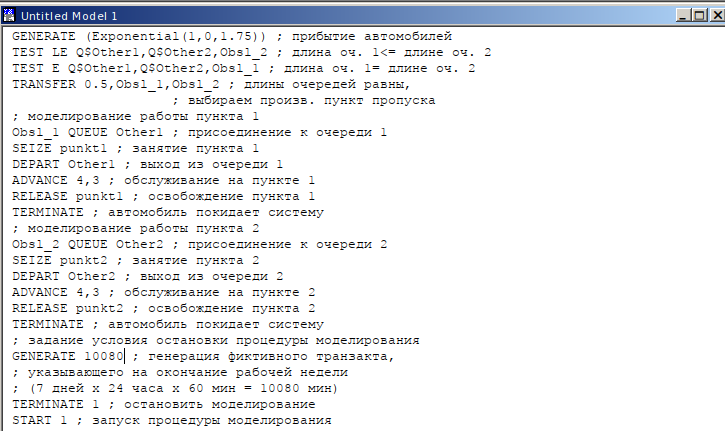

*Модель для первой стратегии с 2 пропускными пунктами*

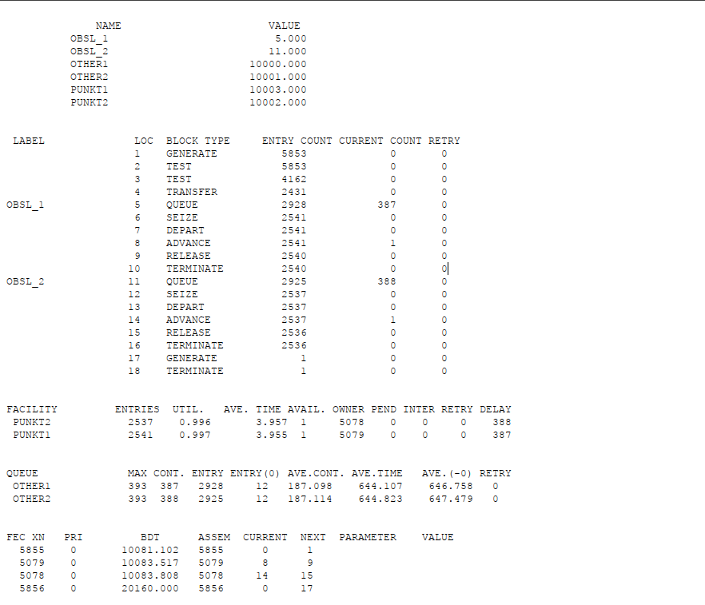

*Отчет по модели для первой стратегии с 2 пропускными пунктами*

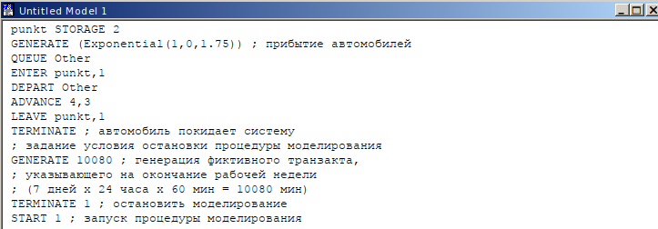

*Модель для второй стратегии с 2 пропускными пунктами*

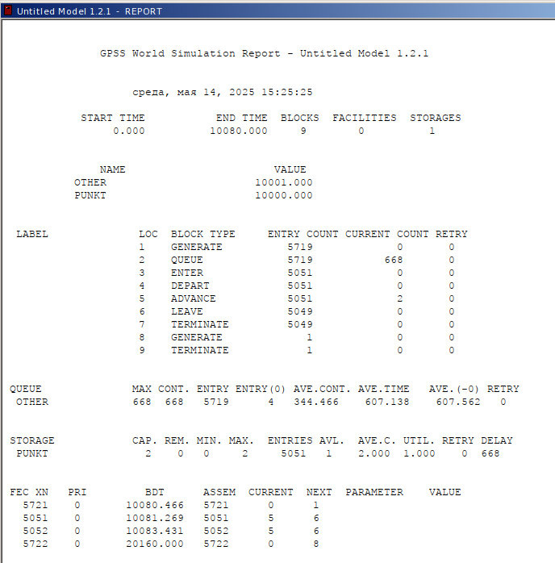

*Отчет по модели для второй стратегии с 2 пропускными пунктами*

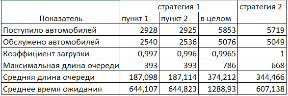

*Сравнение стратегий*

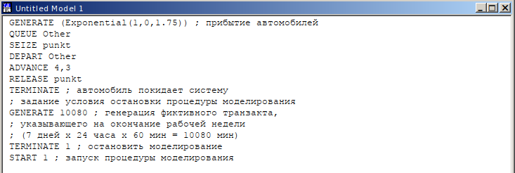

*Модель для обеих стратегий с 1 пропускным пунктом*

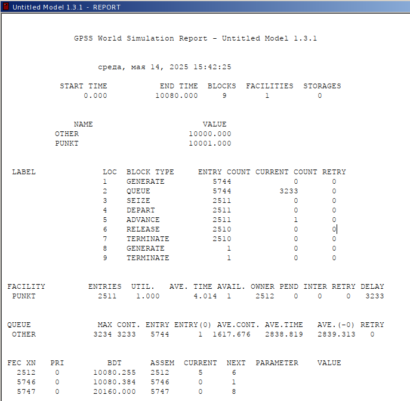

*Отчет по модели для обеих стратегий с 1 пропускным пунктом*

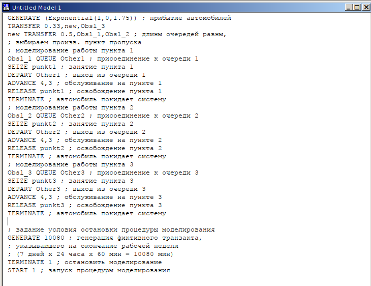

*Модель для первой стратегии с 3 пропускными пунктами*

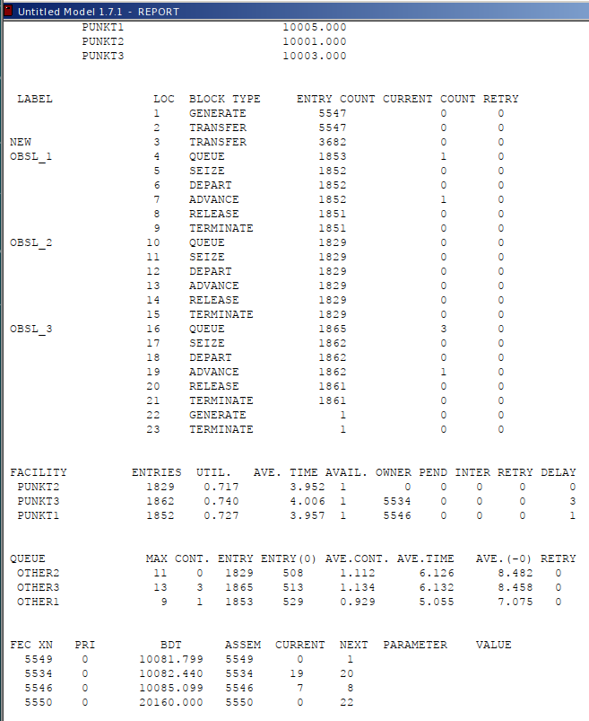

*Отчет по модели для первой стратегии с 3 пропускными пунктами*

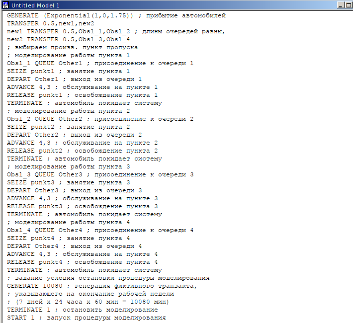

*Модель для первой стратегии с 4 пропускными пунктами*

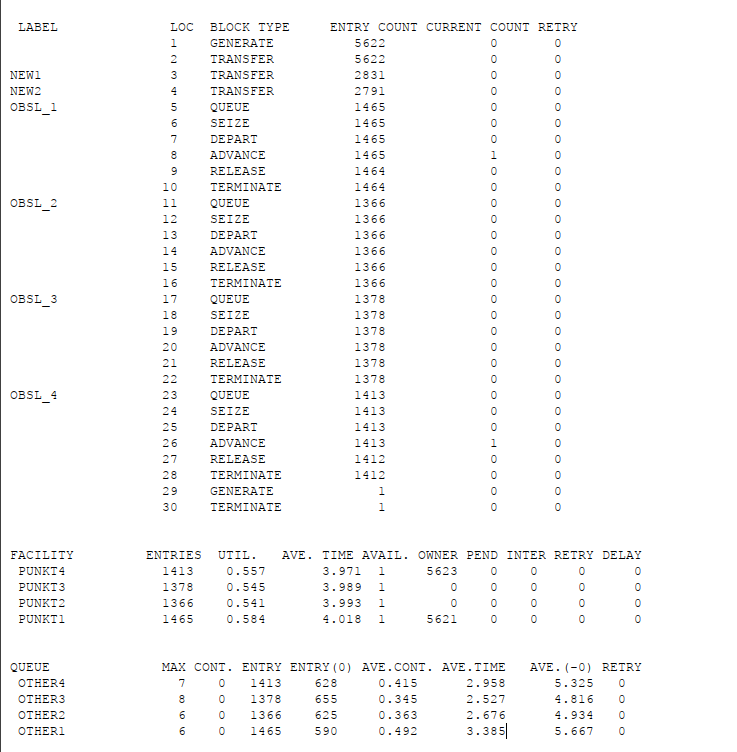

*Отчет по модели для первой стратегии с 4 пропускными пунктами*

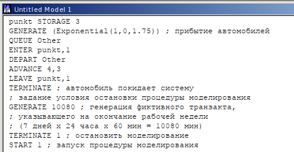

*Модель для второй стратегии с 3 пропускными пунктами*

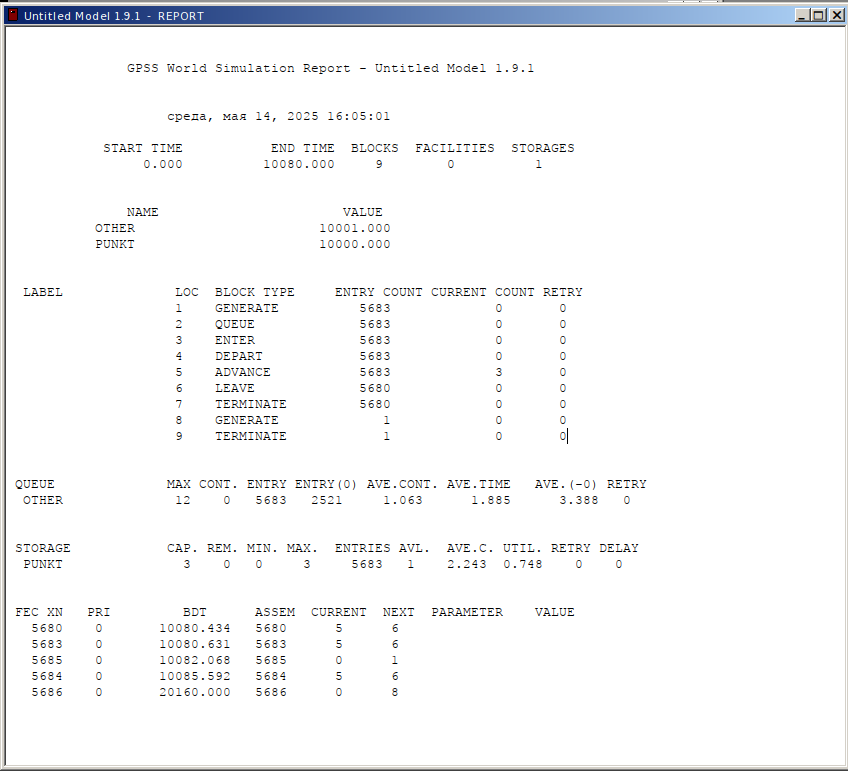

*Отчет по модели для второй стратегии с 3 пропускными пунктами*

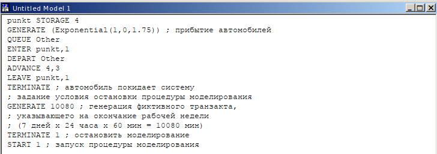

*Модель для второй стратегии с 4 пропускными пунктами*

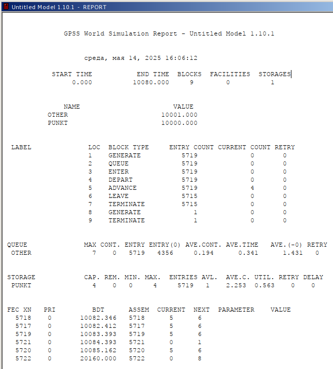

*Отчет по модели для второй стратегии с 4 пропускными пунктами*

# Вывод